# Problem Set Rmarkdown and GGplot

Jordan Lee

2023-02-19

## 1 Load and check data (5pt)

Your first task is to do a very simple data check:

1. (1pt) For solving the problems, and answering the questions, create a new r markdown document with a appropriate title
2. (2pt) Load data. How many rows/columns do we have?

```r
library(tidyverse)
gapminder <- read_delim("../../data/gapminder.csv")
```

The *gapminder* data contains 13055 rows and 25 columns.

3. (2pt) Print a small sample of data. Does it look OK?

```r
gapminder %>%
  sample_n(5) %>%
  knitr::kable()
```

| iso3 | name | iso2 | region | sub-region | intermediate-region | time | totalPopulation | fertilityRate | lifeExpectancy | childMortality | youthFemaleLiteracy | youthMaleLiteracy | adultLiteracy | GDP_PC | accessElectricity | agriculturalLand | agricultureTractors | cerealProduction | fertilizerHa | co2 | greenhouseGases | co2_PC | pm2.5_35 | battleDeaths |
| --- | --- | --- | --- | --- | --- | --- | --- | --- | --- | --- | --- | --- | --- | --- | --- | --- | --- | --- | --- | --- | --- | --- | --- | --- |
| BRN | Brunei Darussalam | BN | Asia | South-eastern Asia | NA | 1969 | 123600 | 5.812 | 62.01300 | 57.5 | NA | NA | NA | NA | NA | 240 | 8 | 6782 | NA | 487.711 | NA | 3.94588 | NA | NA |
| MMR | Myanmar | MM | Asia | South-eastern Asia | NA | 2013 | 51852451 | 2.242 | 64.92100 | 55.8 | NA | NA | NA | 1174.054 | 56.34173 | 125870 | NA | 28622447 | 19.53137 | 13083.856 | NA | 0.25233 | 90.3325 | 278 |
| CZE | Czechia | CZ | Europe | Eastern Europe | NA | 1975 | 10058620 | 2.430 | 70.41463 | NA | NA | NA | NA | NA | NA | NA | NA | NA | NA | NA | 202860.801 | NA | NA | NA |
| PER | Peru | PE | Americas | Latin America and the Caribbean | South America | 2007 | 28333052 | 2.662 | 73.52800 | 23.6 | 96.70523 | 98.01326 | 89.59081 | 4356.739 | 81.98813 | 235680 | NA | 4032733 | 100.56259 | 35071.188 | 70911.513 | 1.23782 | NA | 32 |
| ALB | Albania | AL | Europe | Southern Europe | NA | 1995 | 3187784 | 2.591 | 72.20500 | 33.9 | NA | NA | NA | 1703.282 | NA | 11270 | 8938 | 645400 | 19.06412 | 2086.523 | 6421.571 | 0.65454 | 0.0303 | NA |

The sample looks good !!

## 2 Descriptive satistics (15pt)

1. (3pt) How many countries are there in the dataset? Analyze all three: iso3, iso2 and name.

The *gapminder* data has 3 variables representing countries *iso3, iso2,* and *name*

*iso3* has 253 unique values

*iso2* has 249 unique values

*name* has 250 unique values

2. If you did this correctly, you saw that there are more names than iso-2 codes, and there are even more iso3 -codes. What is going on? Can you find it out?
1. (5pt) Find how many names are there for each iso-2 code. Are there any iso-2 codes that correspond to more than one name? What are these countries?

```r
gapminder %>%
  group_by(iso2) %>%
  summarise(num = n_distinct(name)) %>%
  filter(num > 1)
```

```
## # A tibble: 1 × 2
##   iso2    num
##   <chr> <int>
## 1 <NA>      2
```

Yes, from the code segment output above we see that the only *iso-2* code that correspond to more than one *name* is ‘NA’ (or ‘missing’). This means that there are two different country names with the *iso-2* field missing. Other than this, all other *iso-2* codes correspond to only 1 country name.

2. (5pt) Now repeat the same for name and iso3-code. Are there country names that have more than one iso3-code? What are these countries?

```r
gapminder %>%
  group_by(name) %>%
  summarise(num = n_distinct(iso3)) %>%
  filter(num > 1)
```

```
## # A tibble: 1 × 2
##   name    num
##   <chr> <int>
## 1 <NA>      4
```

Yes, from the code segment output above we see that the only country name that has more than one *iso_3* code is ‘NA’ (or missing). From this we can tell that there are 4 ‘missing’ values in the name field, however, each of them still have/are assigned a different *iso-3* codes.

Hint: two of these entitites are CHANISL and NLD CURACAO.

3. (2pt) What is the minimum and maximum year in these data?

```r
gapminder %>%
  select(time) %>%
  filter(!is.na(time)) %>%
  summarise(max_year = max(time), min_year = min(time))
```

```
## # A tibble: 1 × 2
##   max_year min_year
##      <dbl>    <dbl>
## 1     2019     1960
```

## 3 CO2 Emmisions

Next, let’s analyze CO2 emissions.

1. (2pt) How many missing co2 emissions are there for each year? Analyze both missing CO2 and co2_PC. Which years have most missing data?

```r
gapminder %>%
  group_by(time) %>%
  select(time, co2, co2_PC) %>%
  filter(!is.na(time)) %>%
  summarise(co2_na = sum(is.na(co2)), co2_PC_na = sum(is.na(co2_PC))) %>%
  mutate(sum = co2_na + co2_PC_na) %>%
  arrange(desc(sum))
```

```
## # A tibble: 60 × 4
##     time co2_na co2_PC_na   sum
##    <dbl>  <int>     <int> <int>
##  1  2017    217       217   434
##  2  2018    217       217   434
##  3  2019    217       217   434
##  4  1960     60        60   120
##  5  1961     60        60   120
##  6  1962     58        58   116
##  7  1963     57        57   114
##  8  1964     51        51   102
##  9  1965     51        51   102
## 10  1966     51        51   102
## # … with 50 more rows
```

Years 2017, 2018, 2019 have the most missing *co2* and *co2_PC* fields

2. (5pt) Make a plot of total CO2 emissions over time for the U.S, China, and India. Add a few more countries of your choice. Explain what do you see.

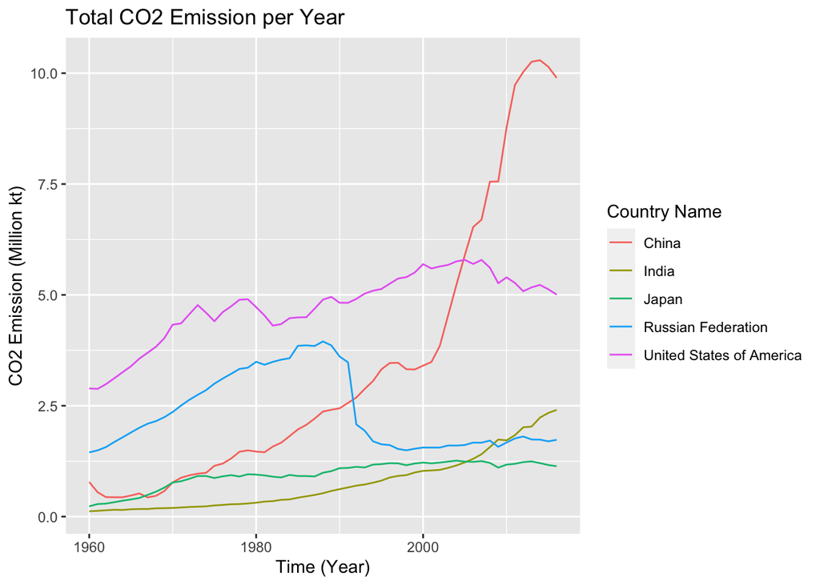

```r
gapminder %>%
  select(name, time, co2) %>%
  filter(!is.na(co2)) %>%
  filter(name %in% c("Japan", "China", "India", "United States of America", "Russian Federation")) %>%
  ggplot(aes(time, co2 / 1000000, col=name)) +
  geom_line() +
  labs(title = "Total CO2 Emission per Year",
       x = "Time (Year)",
       y = "CO2 Emission (Million kt)",
       col = "Country Name")
```

The graph depicts the countries with the highest CO2 Emmisions (kt). From this, we see that China has the highest amount of CO2 emmisions, with the U.S. coming in second amongst the 5 countries for CO2 emmisions. After the year 2000, Russia Japan, and India all hover around the same amount of CO2 emmisions. This graph may indicate a positive relationship between population size and CO2 emmisions

3. (5pt) Now let’s analyze the CO2 emissions per capita (co2_PC ). Make a similar plot of the same countries. What does this figure suggest?

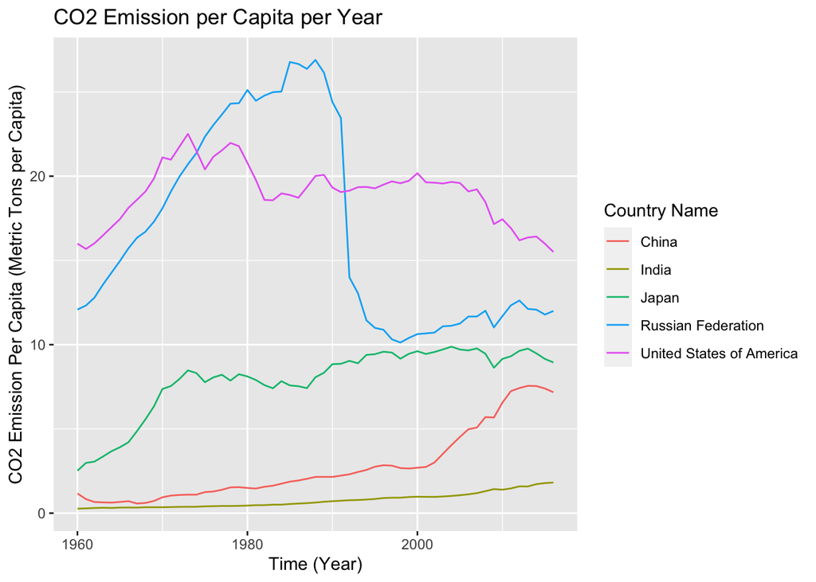

```r
gapminder %>%
  select(name, time, co2_PC) %>%
  filter(!is.na(co2_PC)) %>%
  filter(name %in% c("Japan", "China", "India", "United States of America", "Russian Federation")) %>%
  ggplot(aes(time, co2_PC, col=name)) +
  geom_line() +
  labs(title = "CO2 Emission per Capita per Year",
       x = "Time (Year)",
       y = "CO2 Emission Per Capita (Metric Tons per Capita)",
       col = "Country Name")
```

This graph depicts the amount of CO2 emission per person in a country. China actually has a lower overall CO2 emission per capita compared to other countries (besides India). This is interesting because when comparing this graph to the previous one, China has the largest overall CO2 Emission per year. This suggests that there is a positive relationship between population size and total CO2 emission per year.

4. (6pt) Compute average CO2 emissions per capita across the continents (assume region is the same as continent). Comment what do you see. Note: just compute averages over countries and ignore the fact that countries are of different size. Hint: Americas 2016 should be 4.80.

```r
gapminder %>%
  group_by(region) %>%
  select(region, co2_PC) %>%
  filter(!is.na(region)) %>%
  summarise(avg_co2_PC = mean(co2_PC, na.rm = TRUE))
```

```
## # A tibble: 5 × 2
##   region   avg_co2_PC
##   <chr>         <dbl>
## 1 Africa        0.930
## 2 Americas      6.46
## 3 Asia          6.21
## 4 Europe        7.95
## 5 Oceania       4.39
```

5. (7pt) Make a barplot where you show the previous results–average CO2 emissions per capita across continents in 1960 and 2016.

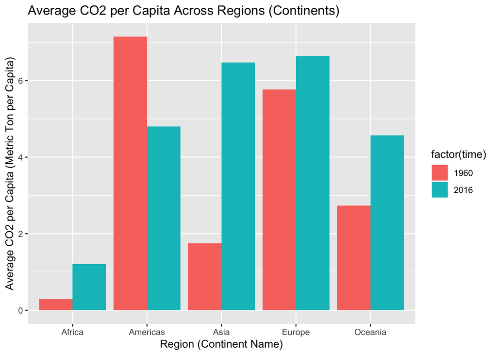

```r
avg_co2 <- gapminder %>%
  select(region, co2_PC, time) %>%
  filter(!is.na(region), time %in% c("1960", "2016")) %>%
  group_by(region, time) %>%
  summarise(avg_co2_PC = mean(co2_PC, na.rm = TRUE))

ggplot(avg_co2, aes(region, avg_co2_PC, fill=factor(time))) +
  geom_col(position = "dodge") +
  labs(title = "Average CO2 per Capita Across Regions (Continents)",
       x = "Region (Continent Name)",
       y = "Average CO2 per Capita (Metric Ton per Capita)",
       col = "Time (Year)")
```

6. Which countries are the three largest, and three smallest CO2 emitters (in terms of CO2 per capita) in 2016 for each continent? (Assume region is continent).

```r
co2_PC_countries <- gapminder %>%
  select(region, name, co2_PC, time) %>%
  filter(time == "2016", !is.na(region), !is.na(co2_PC)) %>%
  arrange(region, desc(co2_PC)) %>%
  group_by(region)
```

Top 3 Countries from each Region

```r
co2_PC_countries %>%
  top_n(3, co2_PC)
```

```
## # A tibble: 15 × 4
## # Groups:   region [5]
##    region   name                     co2_PC  time
##    <chr>    <chr>                     <dbl> <dbl>
##  1 Africa   South Africa               8.48  2016
##  2 Africa   Libya                      7.79  2016
##  3 Africa   Seychelles                 6.39  2016
##  4 Americas Trinidad and Tobago       31.8   2016
##  5 Americas United States of America  15.5   2016
##  6 Americas Canada                    15.1   2016
##  7 Asia     Qatar                     38.9   2016
##  8 Asia     Kuwait                    25.0   2016
##  9 Asia     Bahrain                   22.2   2016
## 10 Europe   Gibraltar                 18.8   2016
## 11 Europe   Luxembourg                15.4   2016
## 12 Europe   Faroe Islands             13.1   2016
## 13 Oceania  New Caledonia             19.3   2016
## 14 Oceania  Australia                 15.5   2016
## 15 Oceania  Palau                     12.6   2016
```

Bottom 3 Countries from each Region

```r
co2_PC_countries %>%
  top_n(-3, co2_PC)
```

```
## # A tibble: 15 × 4
## # Groups:   region [5]
##    region   name                              co2_PC  time
##    <chr>    <chr>                              <dbl> <dbl>
##  1 Africa   Burundi                           0.0472  2016
##  2 Africa   Somalia                           0.0455  2016
##  3 Africa   Congo, Democratic Republic of the 0.0256  2016
##  4 Americas Honduras                          1.06    2016
##  5 Americas Nicaragua                         0.887   2016
##  6 Americas Haiti                             0.275   2016
##  7 Asia     Yemen                             0.390   2016
##  8 Asia     Nepal                             0.334   2016
##  9 Asia     Afghanistan                       0.245   2016
## 10 Europe   Moldova, Republic of              1.83    2016
## 11 Europe   Albania                           1.58    2016
## 12 Europe   Liechtenstein                     1.36    2016
## 13 Oceania  Kiribati                          0.587   2016
## 14 Oceania  Vanuatu                           0.527   2016
## 15 Oceania  Solomon Islands                   0.272   2016
```

## 4 GDP per capita (50pt)

Let’s look at GDP per capita (GDP_PC ).

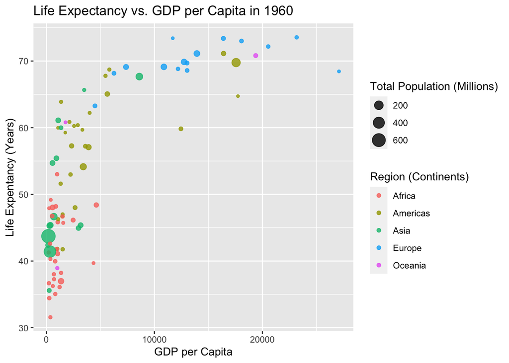

```r
gdp_PC <- gapminder %>%
  group_by(name) %>%
  select(region, GDP_PC, lifeExpectancy, totalPopulation, time) %>%
  filter(time == "1960", !is.na(GDP_PC), !is.na(lifeExpectancy))

ggplot(gdp_PC, aes(GDP_PC, lifeExpectancy, col = factor(region))) +
  geom_point(aes(size=totalPopulation / 1000000), alpha = 0.8) +
  labs(title = "Life Expectancy vs. GDP per Capita in 1960",
       x = "GDP per Capita",
       y = "Life Expentancy (Years)",
       col = "Region (Continents)",
       size = "Total Population (Millions)")
```

2. (4pt) Make a similar plot, but this time use 2019 data only.

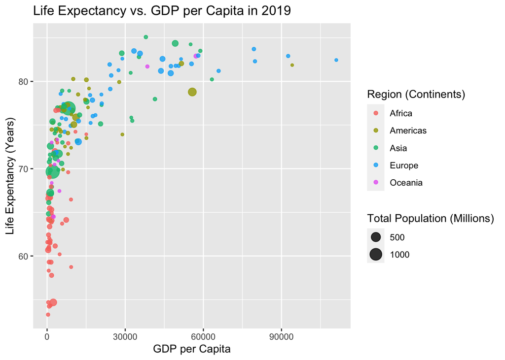

```r
gdp_PC <- gapminder %>%
  group_by(name) %>%
  select(region, GDP_PC, lifeExpectancy, totalPopulation, time) %>%
  filter(time == "2019", !is.na(GDP_PC), !is.na(lifeExpectancy), !is.na(region))

ggplot(gdp_PC, aes(GDP_PC, lifeExpectancy, col = factor(region))) +
  geom_point(aes(size=totalPopulation / 1000000), alpha = 0.8) +
   labs(title = "Life Expectancy vs. GDP per Capita in 2019",
       x = "GDP per Capita",
       y = "Life Expentancy (Years)",
       col = "Region (Continents)",
       size = "Total Population (Millions)")
```

3. (6pt) Compare these two plots and comment what do you see. How has world developed through the last 60 years?

4. (6pt) Compute the average life expectancy for each continent in 1960 and 2019. Do the results fit with what do you see on the figures?

Note: here as average I mean just average over countries, ignore the fact that countries are of different size.

```r
avg_LE <- gapminder %>%
  group_by(region, time) %>%
  select(region, time, lifeExpectancy) %>%
  filter(time %in% c("1960", "2019"), !is.na(region)) %>%
  summarise(avg_LE = mean(lifeExpectancy, na.rm = TRUE))

avg_LE
```

```
## # A tibble: 10 × 3
## # Groups:   region [5]
##    region    time avg_LE
##    <chr>    <dbl>  <dbl>
##  1 Africa    1960   41.5
##  2 Africa    2019   64.1
##  3 Americas  1960   58.6
##  4 Americas  2019   75.8
##  5 Asia      1960   51.6
##  6 Asia      2019   74.6
##  7 Europe    1960   68.3
##  8 Europe    2019   79.4
##  9 Oceania   1960   56.4
## 10 Oceania   2019   73.5
```

5. (8pt) Compute the average LE growth from 1960-2019 across the continents. Show the results in the order of growth. Explain what do you see.

Hint: these data (data in long form) is not the simplest to compute growth. But you may want to check out the lag() function. And do not forget to group data by continent when using lag(), otherwise your results will be messed up!

```r
avg_LE %>%
  group_by(region) %>%
  mutate(prev.val = lag(avg_LE)) %>%
  filter(row_number() %% 2 == 0) %>%
  mutate(avg_growth = avg_LE - prev.val) %>%
  summarise(region, avg_growth) %>%
  arrange(desc(avg_growth))
```

```
## # A tibble: 5 × 2
##   region   avg_growth
##   <chr>         <dbl>
## 1 Asia           23.0
## 2 Africa         22.6
## 3 Americas       17.2
## 4 Oceania        17.1
## 5 Europe         11.1
```

6. (6pt) Show the histogram of GDP per capita for years of 1960 and 2019. Try to put both histograms on the same graph, see how well you can do it!

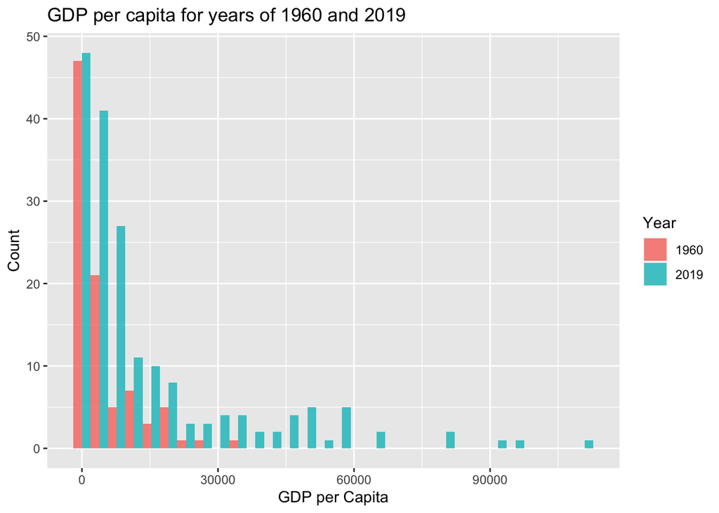

```r
GDP_histogram <- gapminder %>%
  filter(time == "1960" | time == "2019", !is.na(GDP_PC))
ggplot(GDP_histogram, aes(GDP_PC, fill = factor(time))) +
  geom_histogram(alpha = 0.8, position = "dodge", bins = 30) +
  labs(title = "GDP per capita for years of 1960 and 2019",
       x = "GDP per Capita",
       y = "Count",
       fill = "Year")
```

7. (6pt) What was the ranking of US in terms of life expectancy in 1960 and in 2019? (When counting from top.)

Hint: check out the function rank()!

Hint2: 17 for 1960.

```r
ranks_per_year <- gapminder %>%
  select(name, lifeExpectancy, time) %>%
  filter(!is.na(lifeExpectancy), !is.na(name), time %in% c("1960", "2019")) %>%
  arrange(time, desc(lifeExpectancy)) %>%
  group_by(time) %>%
  mutate(rankings = rank(desc(lifeExpectancy)))

ranks_per_year %>%
  filter(name == "United States of America")
```

```
## # A tibble: 2 × 4
## # Groups:   time [2]
##   name                     lifeExpectancy  time rankings
##   <chr>                             <dbl> <dbl>    <dbl>
## 1 United States of America           69.8  1960       17
## 2 United States of America           78.8  2019       46
```

8. (6pt) If you did this correctly, then you noticed that US ranking has been falling quite a bit. But we also have more countries in 2019–what about the relative rank divided by the corresponding number of countries that have LE data in the corresponding year?

Hint: 0.0904 for 1960.

```r
ranks_per_year %>%
  select(name, time, rankings) %>%
  group_by(time) %>%
  mutate(total_n = max(rankings)) %>%
  filter(name == "United States of America") %>%
  summarise(rr_over_ncountries = rankings/total_n)
```

```
## # A tibble: 2 × 2
##    time rr_over_ncountries
##   <dbl>              <dbl>
## 1  1960             0.0904
## 2  2019             0.235
```

## Finally tell us how many hours did you spend on this PS.

10 Hours